# Homework 3, Biostatistics, Fall 2021

Due on 2021/12/20

1. The data set `HEALTH.TXT` is available in the class webpage. The data are taken from the Wisconsin Diabetes Registry Study. The data items are:

   | Variable | Format or code |
   | --- | --- |
   | ID | an unique identification number |
   | HEALTH | self-reported health status: 1=excellent, 2=good, 3=fair, 4=poor |
   | BH | dichotomized health status: 1=excellent health, 0=worse than excellent health |
   | GENDER | sex code: 1=female, 0=male |
   | GHb | mean glycosylated hemoglobin value during the time period |
   | AGE | mean age during the time period (years) |

   Notice that, in this data set, `NA` represents missing values. In the following questions, always use BH as the dependent variable (response variable).
   1. Use logistic regression to obtain the crude odds ratio (and confidence interval) as well as the age adjusted odds ratio for sex versus dichotomized health status (use age as a continuous variable).
   2. Create an age stratum variable (values $1=\mbox{age}\leq 7$, $2=7<\mbox{age}\leq 11$, $3=11<\mbox{age}\leq 15$, $4=15<\mbox{age}$), and corresponding dummy variables, using ages 0-7 as the baseline group.
   3. Use logistic regression to obtain age-stratum adjusted odds ratios for sex versus dichotomized health status. Compare the confidence interval obtained by logistic regression with the one obtained by the stratified 2 $\times$ 2 table approach.
   4. Comment on whether the adjusted odds ratio for sex versus health status is different with the two ways of adjusting for age (i.e., compare adjusting for continuous age versus adjusting for age strata). What assumptions do you make in each way of adjusting for age? Which analysis is more appropriate?
   5. Interpret the odds ratios for age in the two logistic regression approaches above (i.e., one adjusted for continuous age and one adjusted for age strata). Also consider the statistical significance of age in the two regressions.
   6. Add GHb to the logistic regression in Question (c). Does GHb confound the relationships of sex and/or age with health status?
   7. For the model in (f), examine whether GHb interacts with sex in its relationship with binary self reported health status. Interpret the odds ratio for GHb with and without the interaction term between sex and GHb.
2. In this question, we are interested in the relationship between hospitalization in last 6 month (HOSP: 1=yes, 0=no) and self-reported health status (HEALTH: 1=excellenr, 2=good, 3=fair, 4=poor) among children with Type I diabetes. The following grouped data are provided

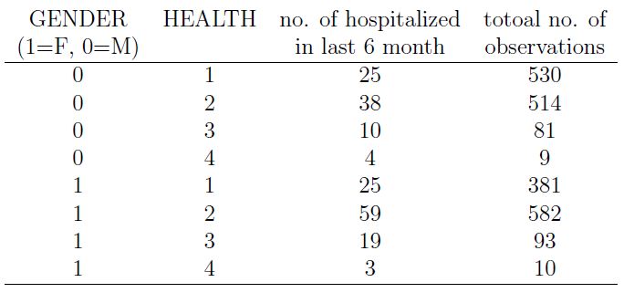

   Three dummy variables are created: HEALTH2 (dummy variable for HEALTH=2), HEALTH3 (dummy variable for HEALTH=3) and HEALTH4 (dummy variable for HEALTH=4).
   1. What is the saturated model for the above grouped data? What is the estimated probability of HOSP=1 for each combination based on the saturated model? Are they the same as the observed probabilities?
   2. Based on the above group data, three other different models were fitted:

      | Model | Variables entered |
      | --- | --- |
      | 1 | Intercept, GENDER, HEALTH2, HEALTH3, HEALTH4 |
      | 2 | Intercept, GENDER, HEALTH |
      | 3 | Intercept, GENDER, HEALTH, GENDER $\times$ HEALTH |

      Perform the likelihood ratio tests to decide which set of covariates is most helpful in predicting HOSP?
   3. Perform the goodness-of-fit tests for all three models in (b). Calcuate the deviance for each model. Is there any model that provides a significantly good fit to the data? What do the goodness-of-fit tests tell you about the interactions between HEALTH (or HEALTH dummy variables) and GENDER?
   4. Further information, `HOSPITAL.TXT`, which contained individual level data of HOSP, GENDER, HEALTH and GHb (glycemic control), were provided (Note: `NA` for missing). Perform logistic regressions of the saturated model and three models described in (a) and (b). Compare your results with the ones got in (a) and (b). Are they the same?
   5. Create the contingency table of GHb (categorized) versus HOSP. Use the table to empirically check the relationship between hospitalization and GHb. Do you think that the square term of GHb is necessary in the logistic regression?
   6. Based on the result of (e), obtain the relationship between HOSP and HEALTH2, HEALTH3, HEALTH4 after adjusting for the potential confounding effcet GHb. To adjust for GHb more convincingly, we group GHb into groups using R `floor(GHb/0.5)`, and fit conditional logistic regression to obtain the GHb-grouping-adjusted relationship. Are results similar from unconditional and conditional logistic regressions?
3. A study was undertaken to assess factors associated with women’s knowledge, attitude and behavior towards mammography. The data, which were published in Hosmer and Lemeshow (1989), can be found in `MES.TXT` with the code sheet for a few of the variables collected in a pilot study listed below.

   | Variable | Codes | Abbreviation |
   | --- | --- | --- |
   | Subject Number | 1-412 | OBS |
   | Mammography Experience (Outcome Variable) | 0=Never, 1=Within the Past Year, 2=Over One Year Ago | ME |
   | "You don’t need a mammogram unless you develop symptoms’’ | 1=Strongly Agree, 2=Agree, 3=Disagree, 4=Strongly Disagree | SYMPT |
   | Perceived Benefit of Mammography* | 5-20 | PB |
   | Mother or Sister with a History of Breast Cancer | 0=No, 1=Yes | HIST |
   | "Has anyone taught you how to examine your own breasts; that is BSE?’’ | 0=No, 1=Yes | BSE |
   | "How likely is it that a mammogram could find a new case of breast cancer?’’ | 1=Not Likely, 2=Somewhat Likely, 3=Very Likely | DETC |

   *The variable PB is the sum of five scaled responses, each on a four point scale. A low value is indicative of a woman with strong agreement with the benefits of mammography.
   1. Create a $2 \times 3$ contingency table with HIST and ME as the variables. Provide a descriptive analysis on the relationship between ME and HIST.
   2. Confirm your finding in (a) by fitting a polytomous logistic regression model with ME as the outcome variable. Perform a likelihood ratio test to test the significance of HIST effect.
   3. Adjusting for SYMPT, PS, HIST and BSE, test whether the association between ME and DETC is significant. Explain your finding (e.g., if not significant, what are the possible explanations?)

   Repeat (a)-(c) using the proportional odds models (be careful about the ordering of the outcome variable).